# Financial Trend Analysis for Microsoft, Tesla, and Apple (2023–2025)

This project analyzes manually extracted 10-K financial data from Microsoft, Tesla, and Apple.

## Objectives:

- Compare financial growth trends
- Calculate year-over-year performance
- Evaluate profitability and financial health
- Derive insights for AI-powered financial chatbot development

```python
import pandas as pd
import matplotlib.pyplot as plt
```

```python
data = [
    ["Microsoft", 2023, 211.9, 72.4, 412.0, 205.8, 87.6],
    ["Microsoft", 2024, 245.1, 88.1, 512.2, 243.7, 118.5],
    ["Microsoft", 2025, 281.7, 101.8, 619.0, 275.5, 136.2],

    ["Tesla", 2023, 96.8, 15.0, 106.6, 43.0, 13.3],
    ["Tesla", 2024, 97.7, 7.2, 122.1, 48.4, 14.9],
    ["Tesla", 2025, 94.8, 3.9, 133.7, 53.0, 14.7],

    ["Apple", 2023, 383.3, 97.0, 352.6, 290.4, 110.5],
    ["Apple", 2024, 391.0, 93.7, 365.0, 308.0, 118.3],
    ["Apple", 2025, 416.2, 112.0, 359.2, 285.5, 122.0]
]

columns = [
    "Company",
    "Year",
    "Total Revenue",
    "Net Income",
    "Total Assets",
    "Total Liabilities",
    "Operating Cash Flow"
]

df = pd.DataFrame(data, columns=columns)

df
```

|  | Company | Year | Total Revenue | Net Income | Total Assets | Total Liabilities | Operating Cash Flow |
| --- | --- | --- | --- | --- | --- | --- | --- |
| 0 | Microsoft | 2023 | 211.9 | 72.4 | 412.0 | 205.8 | 87.6 |
| 1 | Microsoft | 2024 | 245.1 | 88.1 | 512.2 | 243.7 | 118.5 |
| 2 | Microsoft | 2025 | 281.7 | 101.8 | 619.0 | 275.5 | 136.2 |
| 3 | Tesla | 2023 | 96.8 | 15.0 | 106.6 | 43.0 | 13.3 |
| 4 | Tesla | 2024 | 97.7 | 7.2 | 122.1 | 48.4 | 14.9 |
| 5 | Tesla | 2025 | 94.8 | 3.9 | 133.7 | 53.0 | 14.7 |
| 6 | Apple | 2023 | 383.3 | 97.0 | 352.6 | 290.4 | 110.5 |
| 7 | Apple | 2024 | 391.0 | 93.7 | 365.0 | 308.0 | 118.3 |
| 8 | Apple | 2025 | 416.2 | 112.0 | 359.2 | 285.5 | 122.0 |

```python
df.to_csv("financial_data.csv", index=False)
print("CSV saved successfully.")
```

```
CSV saved successfully.
```

```python
df = pd.read_csv("financial_data.csv")
df
```

|  | Company | Year | Total Revenue | Net Income | Total Assets | Total Liabilities | Operating Cash Flow |
| --- | --- | --- | --- | --- | --- | --- | --- |
| 0 | Microsoft | 2023 | 211.9 | 72.4 | 412.0 | 205.8 | 87.6 |
| 1 | Microsoft | 2024 | 245.1 | 88.1 | 512.2 | 243.7 | 118.5 |
| 2 | Microsoft | 2025 | 281.7 | 101.8 | 619.0 | 275.5 | 136.2 |
| 3 | Tesla | 2023 | 96.8 | 15.0 | 106.6 | 43.0 | 13.3 |
| 4 | Tesla | 2024 | 97.7 | 7.2 | 122.1 | 48.4 | 14.9 |
| 5 | Tesla | 2025 | 94.8 | 3.9 | 133.7 | 53.0 | 14.7 |
| 6 | Apple | 2023 | 383.3 | 97.0 | 352.6 | 290.4 | 110.5 |
| 7 | Apple | 2024 | 391.0 | 93.7 | 365.0 | 308.0 | 118.3 |
| 8 | Apple | 2025 | 416.2 | 112.0 | 359.2 | 285.5 | 122.0 |

```python
metrics = [
    "Total Revenue",
    "Net Income",
    "Total Assets",
    "Total Liabilities",
    "Operating Cash Flow"
]

df = df.sort_values(by=["Company", "Year"])

for metric in metrics:
    df[f"{metric} Growth (%)"] = df.groupby("Company")[metric].pct_change() * 100

df["Net Profit Margin (%)"] = (df["Net Income"] / df["Total Revenue"]) * 100
df["Liability-to-Asset Ratio (%)"] = (df["Total Liabilities"] / df["Total Assets"]) * 100

df
```

|  | Company | Year | Total Revenue | Net Income | Total Assets | Total Liabilities | Operating Cash Flow | Total Revenue Growth (%) | Net Income Growth (%) | Total Assets Growth (%) | Total Liabilities Growth (%) | Operating Cash Flow Growth (%) | Net Profit Margin (%) | Liability-to-Asset Ratio (%) |
| --- | --- | --- | --- | --- | --- | --- | --- | --- | --- | --- | --- | --- | --- | --- |
| 6 | Apple | 2023 | 383.3 | 97.0 | 352.6 | 290.4 | 110.5 | NaN | NaN | NaN | NaN | NaN | 25.306548 | 82.359614 |
| 7 | Apple | 2024 | 391.0 | 93.7 | 365.0 | 308.0 | 118.3 | 2.008870 | -3.402062 | 3.516733 | 6.060606 | 7.058824 | 23.964194 | 84.383562 |
| 8 | Apple | 2025 | 416.2 | 112.0 | 359.2 | 285.5 | 122.0 | 6.445013 | 19.530416 | -1.589041 | -7.305195 | 3.127642 | 26.910139 | 79.482183 |
| 0 | Microsoft | 2023 | 211.9 | 72.4 | 412.0 | 205.8 | 87.6 | NaN | NaN | NaN | NaN | NaN | 34.167060 | 49.951456 |
| 1 | Microsoft | 2024 | 245.1 | 88.1 | 512.2 | 243.7 | 118.5 | 15.667768 | 21.685083 | 24.320388 | 18.415938 | 35.273973 | 35.944512 | 47.579071 |
| 2 | Microsoft | 2025 | 281.7 | 101.8 | 619.0 | 275.5 | 136.2 | 14.932681 | 15.550511 | 20.851230 | 13.048831 | 14.936709 | 36.137735 | 44.507270 |
| 3 | Tesla | 2023 | 96.8 | 15.0 | 106.6 | 43.0 | 13.3 | NaN | NaN | NaN | NaN | NaN | 15.495868 | 40.337711 |
| 4 | Tesla | 2024 | 97.7 | 7.2 | 122.1 | 48.4 | 14.9 | 0.929752 | -52.000000 | 14.540338 | 12.558140 | 12.030075 | 7.369498 | 39.639640 |
| 5 | Tesla | 2025 | 94.8 | 3.9 | 133.7 | 53.0 | 14.7 | -2.968270 | -45.833333 | 9.500410 | 9.504132 | -1.342282 | 4.113924 | 39.640987 |

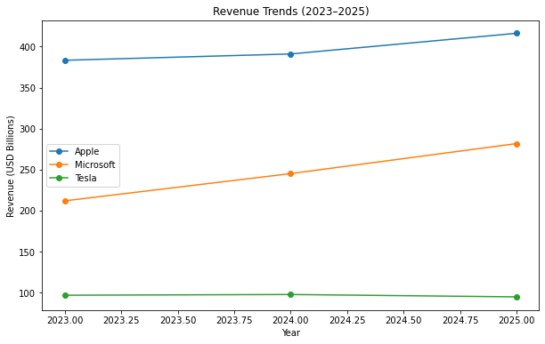

```python
plt.figure(figsize=(10,6))

for company in df["Company"].unique():
    subset = df[df["Company"] == company]
    plt.plot(subset["Year"], subset["Total Revenue"], marker='o', label=company)

plt.title("Revenue Trends (2023–2025)")
plt.xlabel("Year")
plt.ylabel("Revenue (USD Billions)")
plt.legend()
plt.show()
```

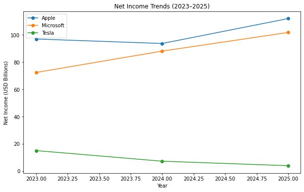

```python
plt.figure(figsize=(10,6))

for company in df["Company"].unique():
    subset = df[df["Company"] == company]
    plt.plot(subset["Year"], subset["Net Income"], marker='o', label=company)

plt.title("Net Income Trends (2023–2025)")
plt.xlabel("Year")
plt.ylabel("Net Income (USD Billions)")
plt.legend()
plt.show()
```

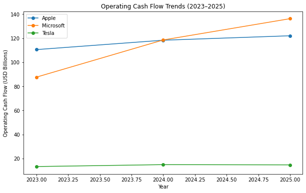

```python
plt.figure(figsize=(10,6))

for company in df["Company"].unique():
    subset = df[df["Company"] == company]
    plt.plot(subset["Year"], subset["Operating Cash Flow"], marker='o', label=company)

plt.title("Operating Cash Flow Trends (2023–2025)")
plt.xlabel("Year")
plt.ylabel("Operating Cash Flow (USD Billions)")
plt.legend()
plt.show()
```

```python
summary = df.groupby("Company")[[
    "Total Revenue",
    "Net Income",
    "Net Profit Margin (%)",
    "Liability-to-Asset Ratio (%)"
]].mean()

summary
```

| Company | Total Revenue | Net Income | Net Profit Margin (%) | Liability-to-Asset Ratio (%) |
| --- | --- | --- | --- | --- |
| Apple | 396.833333 | 100.900000 | 25.393627 | 82.075120 |
| Microsoft | 246.233333 | 87.433333 | 35.416436 | 47.345932 |
| Tesla | 96.433333 | 8.700000 | 8.993097 | 39.872779 |

# Key Findings

## Microsoft

- Strong revenue growth from 2023–2025
- Consistent net income growth
- Significant asset expansion
- Best positioned for AI/cloud scaling

## Tesla

- Revenue stagnation
- Sharp net income decline
- Margin compression despite positive cash flow
- Indicates volatility and competitive pricing pressure

## Apple

- Stable growth profile
- Strong operating cash flow
- Resilient profitability
- Mature, premium business model

# AI-Powered Financial Chatbot Development Insights

This financial dataset can help train a chatbot to:

### Revenue Analysis

- Detect growth leaders
- Compare stagnation vs expansion

### Profitability Intelligence

- Evaluate margin trends
- Flag declining performance

### Financial Risk Detection

- Monitor liabilities
- Assess balance sheet strength

### Investor Decision Support

Example:

- Microsoft = AI growth leader
- Apple = Stability and cash efficiency
- Tesla = Volatility and disruption

# Conclusion

Between 2023 and 2025:

- Microsoft demonstrated the strongest growth trajectory
- Apple maintained stable profitability and resilience
- Tesla showed volatility despite innovation

Using pandas for trend analysis enables creation of intelligent AI financial assistants capable of interpreting:

- Revenue momentum
- Profitability
- Debt health
- Cash flow sustainability

This approach transforms raw 10-K data into actionable financial intelligence.